# Progress

# Initialisation

## Global Variables

- Path to files: raw_real/
- Corpus size: 20437560
- Number of texts in the corpus: 1221
- Occurrences of node: 12354

## Preparation de fichiers

1.La liste de fichiers dans le dossier raw_real/

```
## [1] "raw_real/subc_lemma_Dice.csv, raw_real/subc_lemma_freq.csv, raw_real/subc_lemma_logLike.csv, raw_real/subc_lemma_logRatio.csv, raw_real/subc_lemma_MI3.csv ..."
```

2. Importation de fichiers dans les variables

## Coefficients

1. Calculons et visualisons des correlations entre les rankings

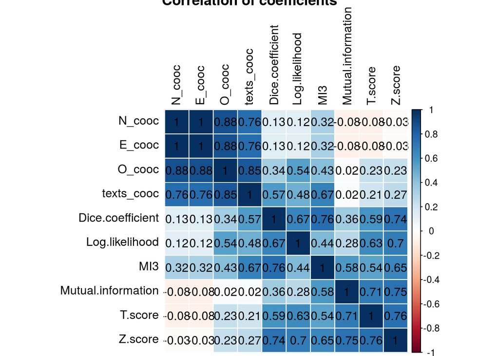

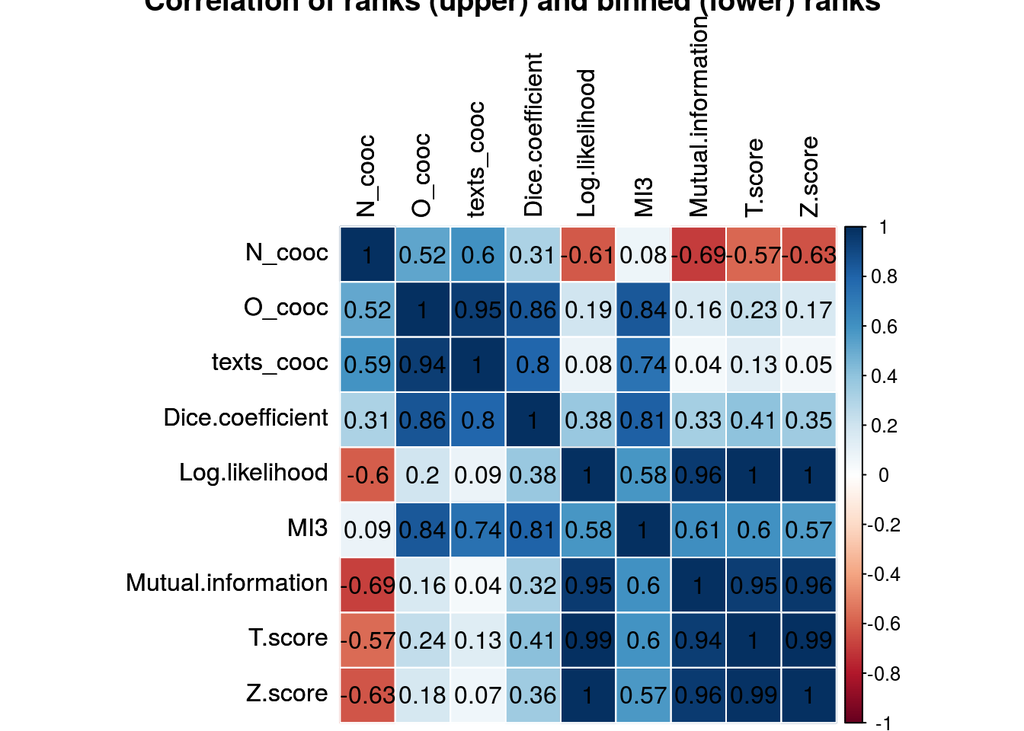

## Distribution

1. Preparation des donnees

### Quelques statistiques

Le moyen nombre des occurrences du mot ‘liber’:  
* par volume: 596  
* par texte: 755

#### Variation

Le nombre des occurrences dans les volumes et les textes est varie:

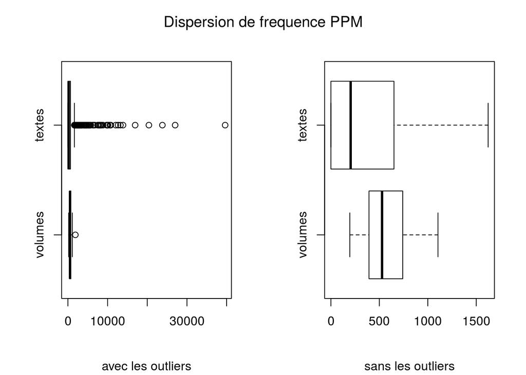

L’inspection des boxplots montre que la frequence du mot est plus variee dans les textes que dans les volumes. Ce sont aussi des textes qui contiennent des grands outliers et la grand partie (`522`, donc ca. `43` %) de textes ne contient aucune occurrence du mot. [Dans les volumes elle parait plutot stable]

#### Distribution

La distribution des frequences dans les textes est donc right-skewed:

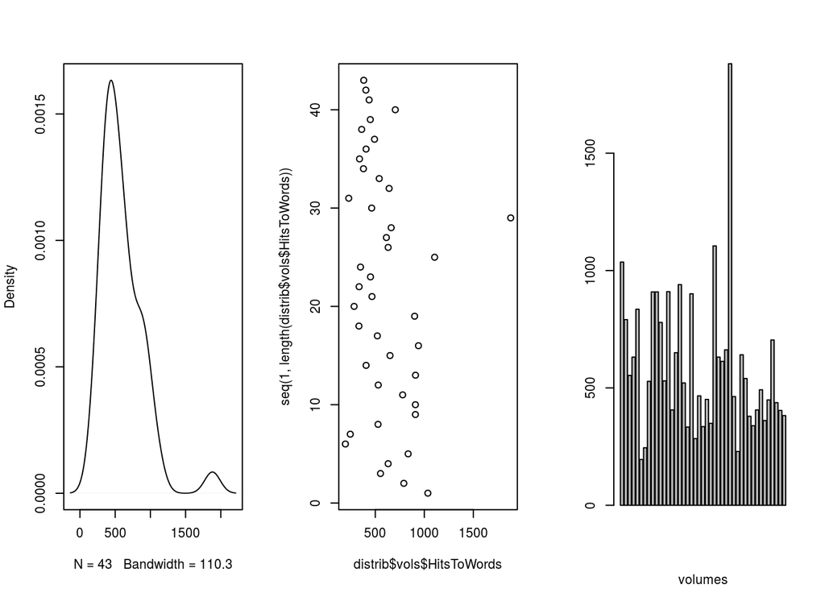

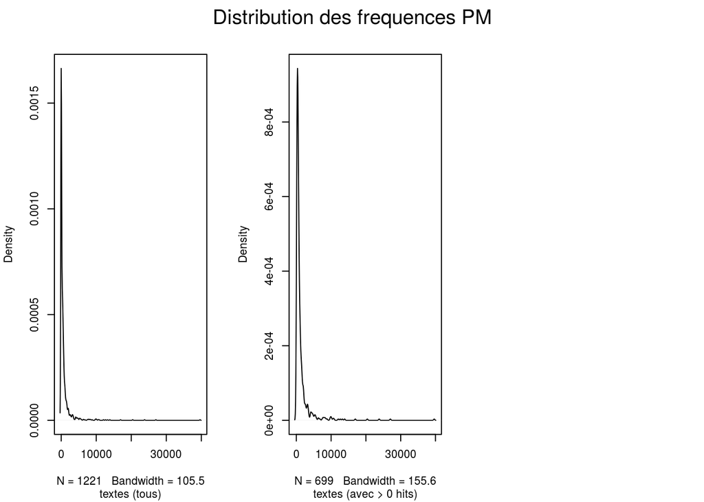

#### Rankings des textes et volumes

Des volumes avec:

- la plus grande frequence du mot

```
##  [1] 125 121  97 112 109 105 106 115 101  98 107
```

- la plus petite frequence du mot

```
##  [1] 102 127 103 116 114 118 131 120 134 130
```

Des textes avec:

- la plus grande frequence du mot

  |  | auteur | titre | Freq..per.million.words |
  | --- | --- | --- | --- |
  | 1170 | Auctores varii | Testimonia veterum et recentiorum | 39627.04 |
  | 609 | Hericus Antissiodorensis | Collectanea | 27027.03 |
  | 779 | Hucbaldus S. Amandi | Epitaphium Milonis | 23809.52 |
  | 936 | Erkembaldus Argentinensis | Poematia | 20408.16 |
  | 418 | Walafridus Strabo | Prophetia Baruch | 16949.15 |
  | 121 | Joannes Trithemius | Vita Smaragdi | 13888.89 |
  | 745 | Notkerus Balbulus | De interpretibus divinarum Scripturarum | 13230.15 |
  | 762 | Auctores varii | Elogia | 12638.23 |
  | 343 | Nicolaus de Lira | Prologus de commendatione Sacrae Scripturae | 12058.57 |
  | 470 | Joannes Trithemius | Vita D. Haymonis | 10810.81 |
  | 693 | Angilbertus Corbeiensis | Versus in librum S. Augustini ad Ludovicum | 10582.01 |

- la plus petite frequence du mot

  |  | auteur | titre | Freq..per.million.words |
  | --- | --- | --- | --- |
  | 11 | Auctor incertus | Carmen | 0.00 |
  | 12 | Auctor incertus | Epitaphium | 0.00 |
  | 13 | Auctor incertus | Genealogia Caroli Magni | 0.00 |
  | 14 | Auctor incertus | Inscriptio codicis | 0.00 |
  | 16 | Auctor incertus | Versus | 0.00 |
  | 17 | Auctores varii | Appendix ad epistolas | 0.00 |
  | 20 | Auctor incertus (Carolus Magnus?) | Sermo de fundatione basilicae | 0.00 |
  | 23 | Carolus Magnus | Diplomata de Italia | 0.00 |
  | 27 | Ludovicus Pius | Privilegium | 0.00 |
  | 32 | Angilbertus Centulensis | Carmina | 0.00 |

- la plus petite frequence du mot (freq > 0)

  |  | auteur | titre | Freq..per.million.words |
  | --- | --- | --- | --- |
  | 209 | Ludovicus Pius | Diplomata ecclesiastica | 15.53 |
  | 408 | Walafridus Strabo | Evangelium secundum Lucam | 19.19 |
  | 142 | Basilius Caesareae | Regula S. Basilii | 32.06 |
  | 1208 | Joannes Venetus | Chronicon Venetum et Grandense | 33.64 |
  | 576 | Adrianus II | Epistola et decreta | 36.24 |
  | 949 | Hrothsuita Gandersheimensis | Comoediae | 42.67 |
  | 667 | Joannes VIII | Epistolae et decreta | 44.61 |
  | 1191 | Gerbertus Auriliacensis | De geometria | 47.85 |
  | 875 | Joannes XIII | Epistolae et decreta | 50.56 |
  | 539 | Grimaldus Sangallensis | Praefationes antiquae | 58.89 |

- par l’auteur
- les auteurs avec le plus de mots PM

```r
print( xtable ( auteurs[1:10,] ), type = "html", col="blue" )
```

|  | auteur | hits | titres | tokens | PM |
| --- | --- | --- | --- | --- | --- |
| 45 | Angilbertus Corbeiensis | 4.00 | Versus in librum S. Augustini ad Ludovicum | 378 | 10582.00 |
| 5 | Adalbertus Metensis | 6.00 | Prologus ad Herimannum presbyterum | 593 | 10118.00 |
| 232 | Josephus discipulus Alcuini | 3.00 | Versus | 355 | 8451.00 |
| 271 | Nicolaus de Lira | 40.00 | Prologus de commendatione Sacrae Scripturae, Prologus de intentione auctoris, Prologus in moralitates Bibliorum | 5538 | 7223.00 |
| 276 | Odalricus Rhemensis | 1.00 | Sententia contra sacrilegos | 190 | 5263.00 |
| 208 | Isaacus Lingonensis | 71.00 | Canones | 14675 | 4838.00 |
| 221 | Joannes Trithemius | 68.00 | Vita Smaragdi, Vita altera Rabani Mauri, Vita D. Haymonis | 15757 | 4316.00 |
| 207 | Hunbertus episcopus | 3.00 | Epistola | 732 | 4098.00 |
| 131 | Cyprianus Cordubensis | 2.00 | Epigrammata | 527 | 3795.00 |
| 320 | Rudolfus scholasticus | 35.00 | Vita Rabani Mauri | 10995 | 3183.00 |

- les auteurs avec le plus de mots PM (freq > 20)

```r
print( xtable ( auteurs[auteurs$hits > 20,][1:10,] ), type = "html", col="blue" )
```

|  | auteur | hits | titres | tokens | PM |
| --- | --- | --- | --- | --- | --- |
| 271 | Nicolaus de Lira | 40.00 | Prologus de commendatione Sacrae Scripturae, Prologus de intentione auctoris, Prologus in moralitates Bibliorum | 5538 | 7223.00 |
| 208 | Isaacus Lingonensis | 71.00 | Canones | 14675 | 4838.00 |
| 221 | Joannes Trithemius | 68.00 | Vita Smaragdi, Vita altera Rabani Mauri, Vita D. Haymonis | 15757 | 4316.00 |
| 320 | Rudolfus scholasticus | 35.00 | Vita Rabani Mauri | 10995 | 3183.00 |
| 48 | Antonius Hispalensis | 46.00 | Disquisitio | 15506 | 2967.00 |
| 17 | Aeneas Parisiensis | 98.00 | Liber adversus Graecos | 35060 | 2795.00 |
| 113 | Carolus Magnus; Lotharius I Germaniae; Ludovicus I Franciae | 171.00 | Capitularia | 69079 | 2475.00 |
| 11 | Adrianus I | 61.00 | Epistola | 25828 | 2362.00 |
| 172 | Gotteschalcus Orbacensis | 24.00 | Confessio, Confessio prolixior, Epistola, Fragmenta omnia | 10334 | 2322.00 |
| 129 | Conventus Parisiensis | 66.00 | Acta | 34033 | 1939.00 |

- les auteurs avec le moins de mots PM

```r
  print( xtable ( auteurs[(nrow(auteurs)-10):nrow(auteurs),]  ), type = "html", col="red" )
```

|  | auteur | hits | titres | tokens | PM |
| --- | --- | --- | --- | --- | --- |
| 343 | Teraldus | 0.00 | Epistola ad Guidonem | 445 | 0.00 |
| 345 | Theodericus Metensis | 0.00 | Epitaphium Evrardi comitis, Inventio sanctorum | 2402 | 0.00 |
| 346 | Theodgaudus I Belgicae Galliae; Guntharius Coloniensis; Arduicus Vestonionensis | 0.00 | Epistola, Epistola | 1264 | 0.00 |
| 350 | Theudoinus Catalaunensis | 0.00 | Epistola | 480 | 0.00 |
| 353 | Thietpaldus Tegernseensis | 0.00 | Epistola ad S. Adelbertum | 257 | 0.00 |
| 354 | Udalricus Augustanus | 0.00 | Charta | 371 | 0.00 |
| 356 | Utho Argentinensis | 0.00 | Vita S. Arbogasti | 1571 | 0.00 |
| 357 | Vigilius diaconus | 0.00 | Regula orientalis | 2872 | 0.00 |
| 358 | Vulfadus Bituricensis | 0.00 | Epistola pastoralis | 2382 | 0.00 |
| 361 | Walterius Senonensis | 0.00 | Statuta | 639 | 0.00 |
| 363 | Wiboldus Cameracensis | 0.00 | Ludus clericalis | 2531 | 0.00 |

- par titre

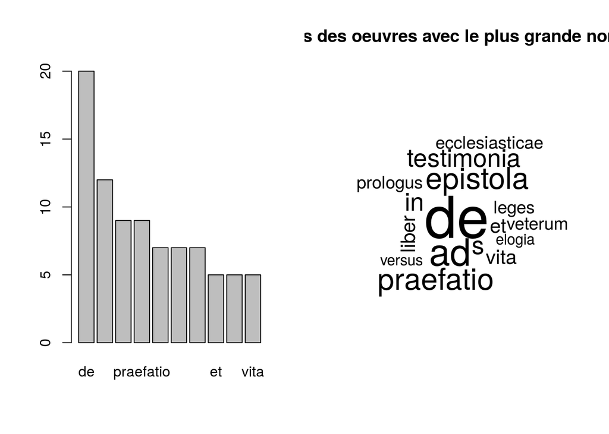

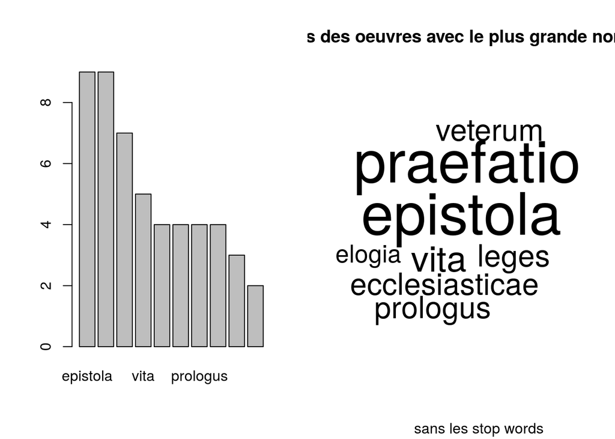

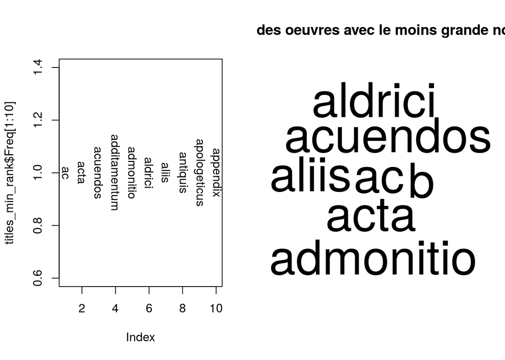

## Wordcloud des co-occurrences (Dice)

### Mots

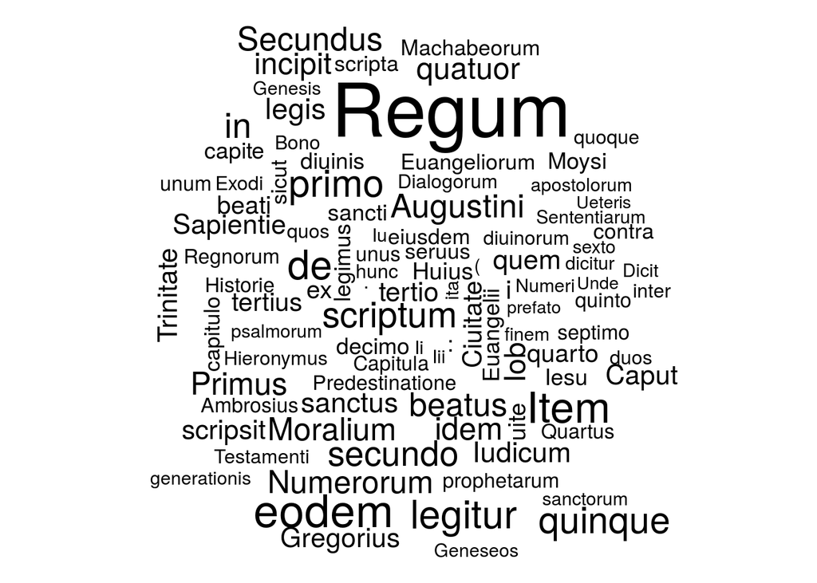

### Lemmes

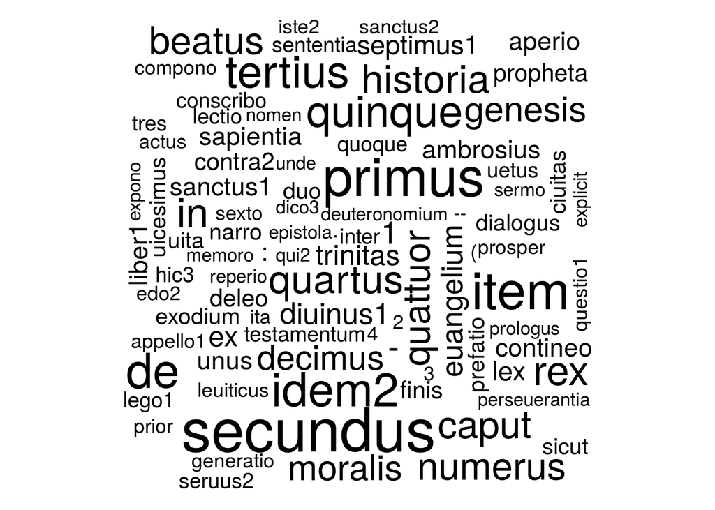

# Clustering de cooccurrences

1. La methode: semantique distributionelle Evert 2014: “Distributional semantic models (DSMs) represent the meaning of a target term (which can be a word form, lemma, morpheme, word pair, etc.) in the form of a feature vector that records either co-occurrence frequencies of the target term with a set of feature terms (term-term model) or its distribution across text units (term-context model)”
2. L’outil: pacquet R wordspace Evert, Stefan. „Distributional Semantics in R with the wordspace Package.” W Proceedings of COLING 2014, the 25th International Conference on Computational Linguistics: System Demonstrations, 110–14. Dublin, Ireland: Dublin City University and Association for Computational Linguistics, 2014. http://anthology.aclweb.org/C/C14/C14-2024.pdf.
3. Session

```r
library(wordspace)
```

### Read-in data

The data should come in the following format:

| target term | feature term | frequency |
| --- | --- | --- |
| liber1_SUB | quintus_QLF | 153 |
| liber1_SUB | lego1_VBE | 6988 |

### Creation de modeles

```
## [1] 28268 28268
```

### On limite la matrix au mots qui ont au moins 3 nonzero frequences

### Weighting counts by log-likelikood

> Evert 2014: “Co-occurrence counts are then weighted by the log-likelihood association measure, log-transformed to deskew their distribution, and row vectors are normalized to Euclidean unit length”

### Dimensionality reduction with SVD algorithm

### Usage du modele: trouver des mots synonymes

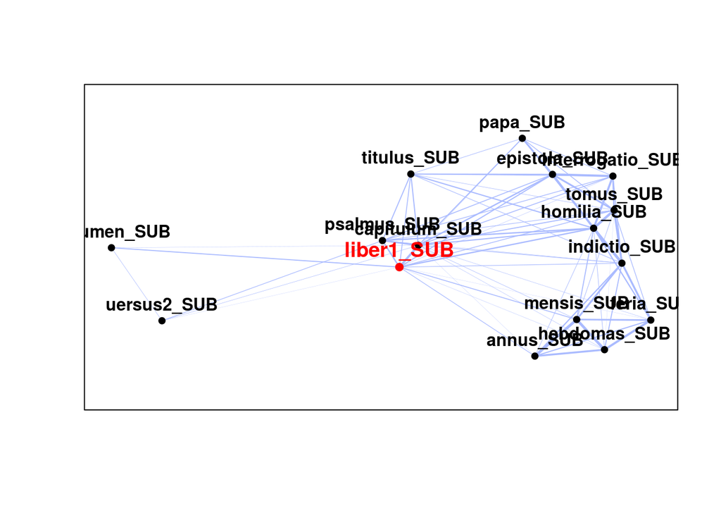

### Usage du modele: clustering de collocations

1. Read-in the collocations
2. Calcule les coefficients de la similarite entre chaque collocation.

Le choix de la methode du calcul de distances: manhattan, mais cp. > the Euclidean and Manhattan distance metrics … turn out to be especially sensitive to extreme values (Juraffsky, Martin 698)

3. Plot tous les coefficients

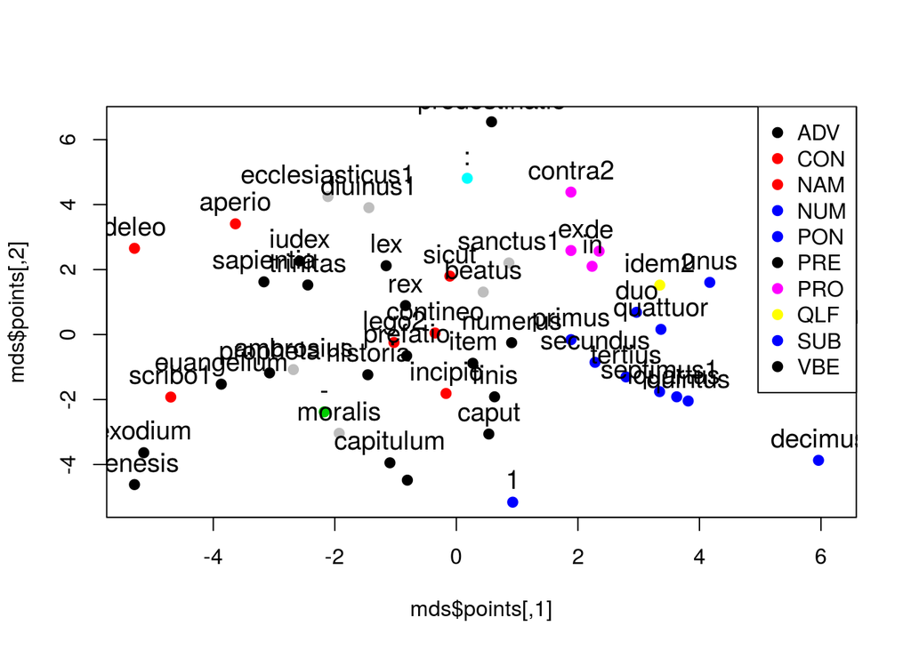

4. Plot uniquement SUB

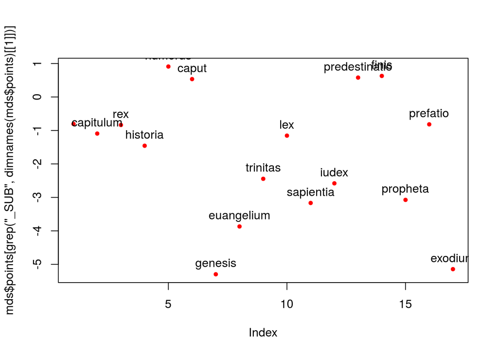